# Violin Plots

# Assignment

In the paper [“The NORAD lncRNA assembles a topoisomerase complex critical for genome stability (Munschauer et al., 2018)”](https://www.nature.com/articles/s41586-018-0453-z), authors investigate the role of human long non-coding RNA- specifically *NORAD* - non-coding RNA activated by DNA damage, which has recently been shown to be required for maintaining genomic stability through a previously unknown mechanism. In order to do this they combined RNA FISH and mass spectrometry to identify proteins that directly interact with *NORAD* in living cells. The authors use a violin plot in figure 2b:

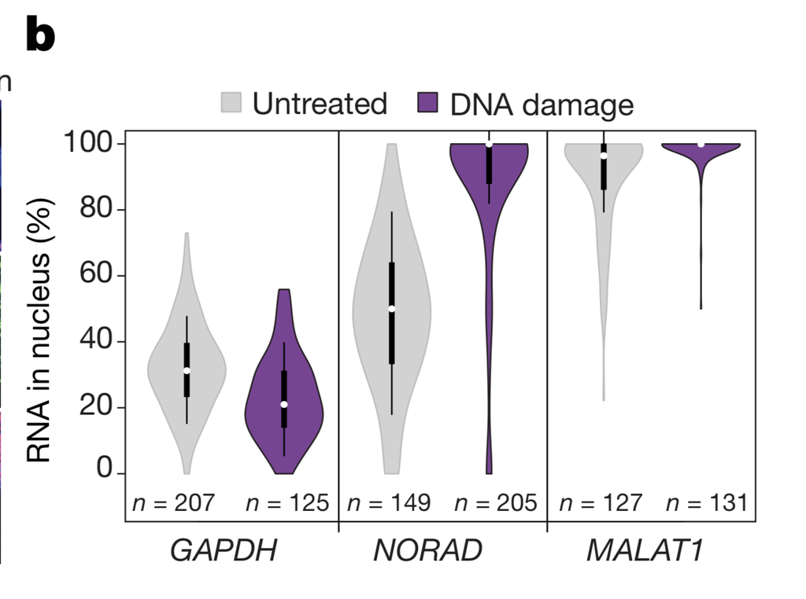

Figure 2b

1. In figure 2b, what question were the researchers trying to answer?
   - What kind of data is being plotted in figure 2b?
   - Why did the authors choose a violin plot to represent these data?
   - What was the sample size of this dataset?
2. In this panel, boxplots are inset in the violin plots. Why did the authors choose to supplement the violin plots with boxplots?
   - What do the various features of these boxplots represent? (ie. box, whiskers, circle)
3. (The authors state that this plot is representative of four independent experiments. What kind of statistical tests would be appropriate to determine if all four replicates are usable? Are such tests required?)

#Plotting

The dataset “boxplot_data.csv” contains data that can be used to practice plotting. Using this data, try to plot:

- a boxplot
- a violin plot
- a jitter (dot) plot
- a violin plot with an inset boxplot
- a combined boxplot and jitter plot

Which plots are the most useful? Try playing around with the color, fill, and width parameters to make the plots easiest to read.

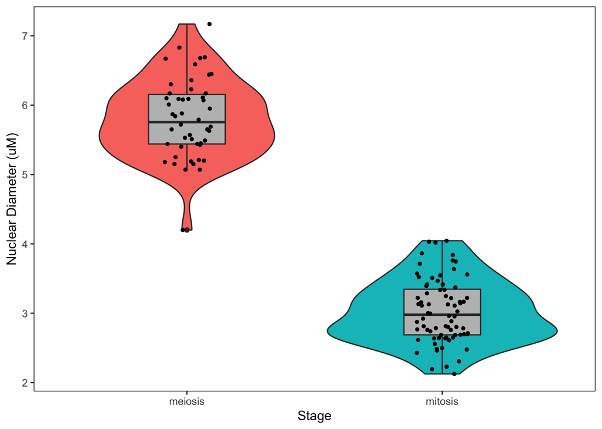

```r
library(ggplot2)
box_data <- as.data.frame(read.csv("boxplot_data.csv"))

box_data_plot <- ggplot(box_data, aes(x=Stage, y=Nucleus_Size,
                                      fill= Stage)) +
  geom_violin() +
  geom_boxplot(fill="gray", width=0.3) +
  geom_jitter(width = 0.1, size=1)+
  theme(panel.background=element_blank(),
        strip.background = element_blank(),
        panel.border=element_rect(colour="black",fill=NA),
        legend.title = element_blank(),
        legend.position="none")+
  xlab("Stage")+
  ylab("Nuclear Diameter (uM)")

box_data_plot
```